# Homework 7 - Better Visualization

Annie Hou

04/16/2024

### Load packages and data

```r
library(tidyverse)
```

### Exercise 1

The graph is misleading because of the dual-axis design that doesn’t share the same scale: the left vertical axis for mask counties ranges from 15 to 25, whereas the right vertical axis for no-mask counties ranges from 4 to 14. Therefore, the two respective curves can be misleading to people because it can mislead people to think the trends are similar and under the same scale. However, they are actually not under a consistent scale for comparison.

### Exercise 2

The data frame should contain variables (columns) including: date, the number of cases per 100k population in counties with a mask mandate, and the number of cases per 100k population in counties without a mask mandate.

### Exercise 3

Based on the horizontal axis, the data frame should contain 23 observations (rows).

### Exercise 4

```r
dates <- seq(as.Date("2020-07-12"), as.Date("2020-08-03"), by="days")
cases_per_100k_mask <- c(26, 20, 20, 21, 20, 20, 21, 20, 21, 22, 21, 20, 20, 21, 20, 19, 18, 18, 17, 17, 16.5, 16, 16)
cases_per_100k_no_mask <- c(10, 9, 10, 10, 9.5, 9, 8, 8, 8, 8.5, 8.5, 8.5, 9.8, 10, 10, 9.5, 9.5, 9.5, 10, 8.5, 9, 8.5, 9)

df <- data.frame(
  Date = dates,
  Cases_Per_100K_Mask = cases_per_100k_mask,
  Cases_Per_100K_No_Mask = cases_per_100k_no_mask
)

print(df)
```

```
##          Date Cases_Per_100K_Mask Cases_Per_100K_No_Mask
## 1  2020-07-12                26.0                   10.0
## 2  2020-07-13                20.0                    9.0
## 3  2020-07-14                20.0                   10.0
## 4  2020-07-15                21.0                   10.0
## 5  2020-07-16                20.0                    9.5
## 6  2020-07-17                20.0                    9.0
## 7  2020-07-18                21.0                    8.0
## 8  2020-07-19                20.0                    8.0
## 9  2020-07-20                21.0                    8.0
## 10 2020-07-21                22.0                    8.5
## 11 2020-07-22                21.0                    8.5
## 12 2020-07-23                20.0                    8.5
## 13 2020-07-24                20.0                    9.8
## 14 2020-07-25                21.0                   10.0
## 15 2020-07-26                20.0                   10.0
## 16 2020-07-27                19.0                    9.5
## 17 2020-07-28                18.0                    9.5
## 18 2020-07-29                18.0                    9.5
## 19 2020-07-30                17.0                   10.0
## 20 2020-07-31                17.0                    8.5
## 21 2020-08-01                16.5                    9.0
## 22 2020-08-02                16.0                    8.5
## 23 2020-08-03                16.0                    9.0
```

### Exercise 5

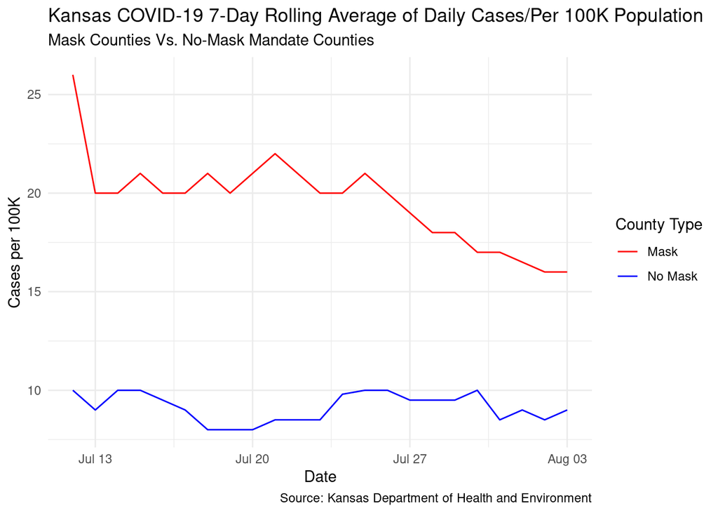

```r
ggplot(data = df, aes(x = Date)) +
  geom_line(aes(y = Cases_Per_100K_Mask, colour = "Mask")) +
  geom_line(aes(y = Cases_Per_100K_No_Mask, colour = "No Mask")) +
  labs(
    title = "Kansas COVID-19 7-Day Rolling Average of Daily Cases/Per 100K Population",
    subtitle = "Mask Counties Vs. No-Mask Mandate Counties",
    caption = "Source: Kansas Department of Health and Environment",
    x = "Date",
    y = "Cases per 100K",
    colour = "County Type"
  ) +
  scale_colour_manual(values = c("Mask" = "red", "No Mask" = "blue")) +
  theme_minimal()
```

### Exercise 6

The revised visualization is more clear in using a single vertical axis for both the mask and no-mask county data, so that the comparison between these two is more direct and not distorted by the originally inconsistent scales. Now, we could easily compare these two curves without misleading axes. The relationship between the number of cases for mask and non-mask mandates counties can be directly and accurately reflected.